# Melbourne Pedestrian Mobility Analytics 2026

- Show All Code
- Hide All Code
- View Source

Exploring and Predicting Pedestrian Activity Across Melbourne

Author

Mani Jabbari

Published

August 16, 2026

# Project Overview

Melbourne’s pedestrian activity varies substantially across locations, days and times, creating a forecasting problem relevant to urban planning, transport operations and resource allocation.

This project analyses **505,887 hourly pedestrian observations** from the City of Melbourne’s 2026 Pedestrian Counting System to answer three questions:

1. **When and where is pedestrian demand highest?**
2. **Which factors are most strongly associated with pedestrian demand?**
3. **How accurately can future pedestrian activity be predicted using machine learning?**

The project follows an end-to-end workflow including data validation, exploratory analysis, statistical testing, feature engineering, predictive modelling, model evaluation, explainability and responsible AI considerations.

## Executive Summary

This project analyses more than 500,000 hourly pedestrian observations from the City of Melbourne’s 2026 Pedestrian Counting System to understand urban mobility patterns and predict pedestrian demand across sensor locations.

The analysis combines exploratory data analysis, statistical testing and machine learning. Models were trained using January–July 2026 observations and evaluated on unseen observations from 1–13 August 2026, preserving chronological order to simulate forecasting future pedestrian demand.

The analysis found that **sensor location and hour of day are the strongest predictors of pedestrian demand**. Demand varies substantially across locations and throughout the day, while unusually large demand spikes remain more difficult to predict using location and temporal information alone.

These findings demonstrate how machine learning can support data-driven urban mobility planning while also highlighting the importance of external contextual data and responsible model monitoring.

## Data Source

The analysis uses open pedestrian sensor data published by the City of Melbourne.

Gradient boosting produced the strongest overall performance, achieving an R² of 0.895, MAE of 98.14 pedestrians per sensor-hour, and RMSE of 184.49, substantially outperforming the baseline, linear regression and random forest models.

**Analysis period:** 1 January 2026 – 14 August 2026  
**Observations:** 505,887 hourly sensor records  
**Unique sensor locations represented in the count data:** 101  
**Target variable:** Hourly pedestrian count (`Total_of_Directions`)

The data is publicly available through the City of Melbourne Open Data platform.

# Data Loading

```python
import pandas as pd
import numpy as np
import matplotlib.pyplot as plt

df = pd.read_csv("data/pedestrian_counts_2026.csv")

print("Number of rows:", df.shape[0])
print("Number of columns:", df.shape[1])

df.head()
```

[output not shown]

# Data Understanding

Before conducting the analysis, the structure, variable types, missing values, and coverage of the dataset are examined.

```python
# Display all column names
print(df.columns.tolist())

# Display data types and non-missing observations
df.info()

# Display summary statistics for numerical variables
df.describe()
```

```
['ID', 'Location_ID', 'Sensing_Date', 'HourDay', 'Direction_1', 'Direction_2', 'Total_of_Directions', 'Sensor_Name', 'Location']
<class 'pandas.DataFrame'>
RangeIndex: 505887 entries, 0 to 505886
Data columns (total 9 columns):
 #   Column               Non-Null Count   Dtype
---  ------               --------------   -----
 0   ID                   505887 non-null  int64
 1   Location_ID          505887 non-null  int64
 2   Sensing_Date         505887 non-null  str
 3   HourDay              505887 non-null  int64
 4   Direction_1          505887 non-null  int64
 5   Direction_2          505887 non-null  int64
 6   Total_of_Directions  505887 non-null  int64
 7   Sensor_Name          504870 non-null  str
 8   Location             504870 non-null  str
dtypes: int64(6), str(3)
memory usage: 34.7 MB
```

|  | ID | Location_ID | HourDay | Direction_1 | Direction_2 | Total_of_Directions |
| --- | --- | --- | --- | --- | --- | --- |
| count | 5.058870e+05 | 505887.000000 | 505887.000000 | 505887.000000 | 505887.000000 | 505887.000000 |
| mean | 5.192915e+11 | 80.261681 | 11.732164 | 195.274929 | 198.462271 | 393.737200 |
| std | 5.710044e+11 | 57.159360 | 6.800547 | 304.782741 | 308.324447 | 583.987414 |
| min | 1.020261e+09 | 1.000000 | 0.000000 | 0.000000 | 0.000000 | 0.000000 |
| 25% | 6.962026e+10 | 35.000000 | 6.000000 | 18.000000 | 18.000000 | 38.000000 |
| 50% | 2.311203e+11 | 66.000000 | 12.000000 | 77.000000 | 76.000000 | 159.000000 |
| 75% | 7.712203e+11 | 133.000000 | 18.000000 | 236.000000 | 242.000000 | 494.000000 |
| max | 2.092320e+12 | 209.000000 | 23.000000 | 6656.000000 | 8215.000000 | 8807.000000 |

# Data Quality Assessment

Before analysis, the dataset is checked for duplicate observations, missing values, temporal coverage, and consistency between directional and total pedestrian counts.

```python
# Check for duplicate rows
print("Duplicate rows:", df.duplicated().sum())

# Check missing values
print("\nMissing values:")
print(df.isnull().sum())

# Convert Sensing_Date from text to a proper date
df["Sensing_Date"] = pd.to_datetime(df["Sensing_Date"])

# Check date coverage
print("\nDate range:")
print("Start:", df["Sensing_Date"].min())
print("End:", df["Sensing_Date"].max())

# Check number of sensor locations
print("\nUnique location IDs:", df["Location_ID"].nunique())

# Check whether Direction 1 + Direction 2 equals the recorded total
total_mismatch = (
    df["Direction_1"] + df["Direction_2"] != df["Total_of_Directions"]
).sum()

print("Rows where directional counts do not equal total:", total_mismatch)
```

```
Duplicate rows: 0

Missing values:
ID                        0
Location_ID               0
Sensing_Date              0
HourDay                   0
Direction_1               0
Direction_2               0
Total_of_Directions       0
Sensor_Name            1017
Location               1017
dtype: int64

Date range:
Start: 2026-01-01 00:00:00
End: 2026-08-14 00:00:00

Unique location IDs: 101
Rows where directional counts do not equal total: 0
```

# Data Preparation and Feature Engineering

The raw date and hour variables are transformed into features that better represent temporal patterns in pedestrian demand.

```python
# Remove ID because it is only an observation identifier
df = df.drop(columns=["ID"])

# Create calendar features
df["Day_of_Week"] = df["Sensing_Date"].dt.day_name()
df["Day_Number"] = df["Sensing_Date"].dt.dayofweek
df["Month"] = df["Sensing_Date"].dt.month
df["Month_Name"] = df["Sensing_Date"].dt.month_name()

# Identify weekends
df["Weekend"] = (df["Day_Number"] >= 5).astype(int)

# Identify common commuting peak periods
df["Morning_Peak"] = df["HourDay"].between(7, 9).astype(int)
df["Evening_Peak"] = df["HourDay"].between(16, 18).astype(int)

# Display the new variables
df[
    [
        "Sensing_Date",
        "HourDay",
        "Day_of_Week",
        "Month_Name",
        "Weekend",
        "Morning_Peak",
        "Evening_Peak"
    ]
].head(10)
```

|  | Sensing_Date | HourDay | Day_of_Week | Month_Name | Weekend | Morning_Peak | Evening_Peak |
| --- | --- | --- | --- | --- | --- | --- | --- |
| 0 | 2026-08-14 | 0 | Friday | August | 0 | 0 | 0 |
| 1 | 2026-08-14 | 2 | Friday | August | 0 | 0 | 0 |
| 2 | 2026-08-14 | 3 | Friday | August | 0 | 0 | 0 |
| 3 | 2026-08-14 | 1 | Friday | August | 0 | 0 | 0 |
| 4 | 2026-08-14 | 0 | Friday | August | 0 | 0 | 0 |
| 5 | 2026-08-14 | 3 | Friday | August | 0 | 0 | 0 |
| 6 | 2026-08-14 | 1 | Friday | August | 0 | 0 | 0 |
| 7 | 2026-08-14 | 1 | Friday | August | 0 | 0 | 0 |
| 8 | 2026-08-14 | 1 | Friday | August | 0 | 0 | 0 |
| 9 | 2026-08-14 | 0 | Friday | August | 0 | 0 | 0 |

# Exploratory Data Analysis

## Pedestrian Demand by Hour of Day

Pedestrian activity is first examined across the 24-hour day to identify recurring periods of high and low demand.

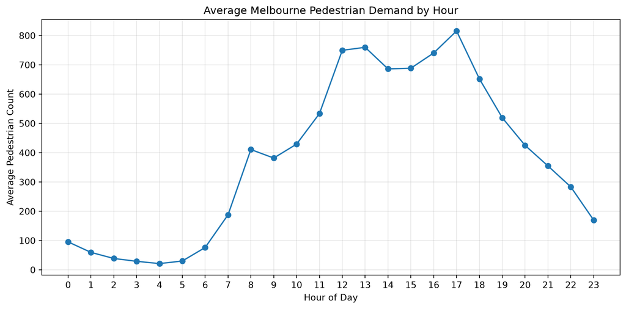

```python
# Calculate average pedestrian count for each hour
hourly_demand = (
    df.groupby("HourDay")["Total_of_Directions"]
      .mean()
      .reset_index()
)

# Plot average demand by hour
plt.figure(figsize=(10, 5))

plt.plot(
    hourly_demand["HourDay"],
    hourly_demand["Total_of_Directions"],
    marker="o"
)

plt.title("Average Melbourne Pedestrian Demand by Hour")
plt.xlabel("Hour of Day")
plt.ylabel("Average Pedestrian Count")
plt.xticks(range(0, 24))
plt.grid(alpha=0.3)
plt.tight_layout()
plt.savefig("figures/hourly_demand.png", dpi=200, bbox_inches="tight")
plt.show()
```

Pedestrian demand displays a strong time-of-day pattern. Activity increases sharply during the morning, remains elevated throughout the middle of the day, and reaches its highest average level at approximately 5 PM. The pronounced afternoon peak suggests that time of day is likely to be an important predictor of pedestrian demand.

## Weekday vs Weekend Demand

To determine whether daily mobility patterns differ between working and non-working days, hourly pedestrian demand is compared between weekdays and weekends.

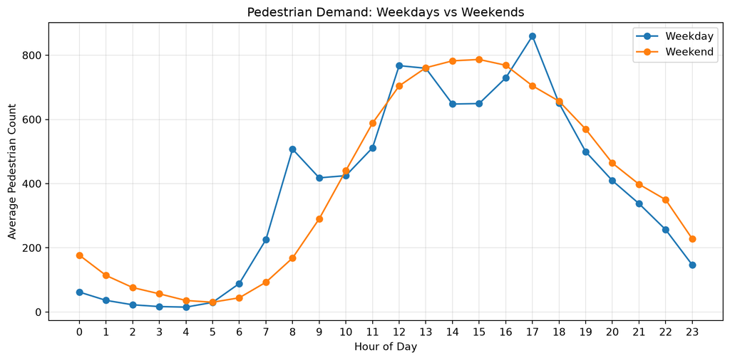

```python
# Create readable labels
df["Day_Type"] = df["Weekend"].map({
    0: "Weekday",
    1: "Weekend"
})

# Calculate average demand by hour and day type
hourly_daytype = (
    df.groupby(["HourDay", "Day_Type"])["Total_of_Directions"]
      .mean()
      .reset_index()
)

# Plot each group
plt.figure(figsize=(10, 5))

for day_type in ["Weekday", "Weekend"]:
    subset = hourly_daytype[hourly_daytype["Day_Type"] == day_type]

    plt.plot(
        subset["HourDay"],
        subset["Total_of_Directions"],
        marker="o",
        label=day_type
    )

plt.title("Pedestrian Demand: Weekdays vs Weekends")
plt.xlabel("Hour of Day")
plt.ylabel("Average Pedestrian Count")
plt.xticks(range(0, 24))
plt.legend()
plt.grid(alpha=0.3)
plt.tight_layout()

plt.show()
```

Weekday and weekend pedestrian activity display distinct temporal patterns. Weekdays show pronounced peaks around 8 AM and 5 PM, while weekend activity rises later and remains comparatively high through the afternoon and evening. This indicates that day type and hour of day are important features for modelling pedestrian demand.

## Location Data Integration

The hourly pedestrian dataset contains sensor identifiers but limited descriptive information about each location. The City of Melbourne sensor-location dataset is therefore joined to the pedestrian counts using the common `Location_ID` field.

```python
# Load the sensor location dataset
locations = pd.read_csv("data/sensor_locations.csv")

# Inspect its structure
print("Rows:", locations.shape[0])
print("Columns:", locations.shape[1])
print("\nColumn names:")
print(locations.columns.tolist())

locations.head()
```

```
Rows: 134
Columns: 12

Column names:
['Location_ID', 'Sensor_Description', 'Sensor_Name', 'Installation_Date', 'Note', 'Location_Type', 'Status', 'Direction_1', 'Direction_2', 'Latitude', 'Longitude', 'Location']
```

|  | Location_ID | Sensor_Description | Sensor_Name | Installation_Date | Note | Location_Type | Status | Direction_1 | Direction_2 | Latitude | Longitude | Location |
| --- | --- | --- | --- | --- | --- | --- | --- | --- | --- | --- | --- | --- |
| 0 | 3 | Melbourne Central | Swa295_T | 2009-03-25 | NaN | Outdoor | A | North | South | -37.811015 | 144.964295 | -37.81101524, 144.96429485 |
| 1 | 5 | Princes Bridge | PriNW_T | 2009-03-26 | Replace with: 00:6e:02:01:9e:54 | Outdoor | A | North | South | -37.818742 | 144.967877 | -37.81874249, 144.96787656 |
| 2 | 9 | Southern Cross Station | Col700_T | 2009-03-23 | NaN | Outdoor | A | East | West | -37.819830 | 144.951026 | -37.81982992, 144.95102555 |
| 3 | 11 | Docklands Waterfront City Building Side | WatCit_T | 2009-01-20 | Device has been replaced with new sensor on 22... | Outdoor | A | East | West | -37.815667 | 144.939744 | -37.81566651, 144.93974366 |
| 4 | 12 | New Quay | NewQ_T | 2009-01-21 | NaN | Outdoor | A | East | West | -37.814580 | 144.942924 | -37.81457988, 144.94292398 |

### Joining Sensor Information to Pedestrian Counts

Relevant location attributes are merged with the hourly pedestrian observations using `Location_ID`.

```python
# Select the location information needed for analysis
location_info = locations[
    [
        "Location_ID",
        "Sensor_Description",
        "Location_Type",
        "Status",
        "Latitude",
        "Longitude"
    ]
].copy()

# Join location information to the pedestrian count data
df = df.merge(
    location_info,
    on="Location_ID",
    how="left"
)

# Check how successful the join was
print("Rows after join:", len(df))
print("Missing sensor descriptions:", df["Sensor_Description"].isna().sum())

# Preview the combined data
df[
    [
        "Sensing_Date",
        "HourDay",
        "Location_ID",
        "Sensor_Description",
        "Total_of_Directions"
    ]
].head(10)
```

```
Rows after join: 505887
Missing sensor descriptions: 1017
```

|  | Sensing_Date | HourDay | Location_ID | Sensor_Description | Total_of_Directions |
| --- | --- | --- | --- | --- | --- |
| 0 | 2026-08-14 | 0 | 68 | Flinders Ln -Degraves St (North) | 17 |
| 1 | 2026-08-14 | 2 | 35 | Southbank Promenade | 11 |
| 2 | 2026-08-14 | 3 | 24 | Spencer St-Collins St (North) | 17 |
| 3 | 2026-08-14 | 1 | 164 | I-Hub 526 La Trobe Street (Footpath) | 5 |
| 4 | 2026-08-14 | 0 | 37 | Lygon St (East) | 26 |
| 5 | 2026-08-14 | 3 | 70 | Errol Street (East) | 2 |
| 6 | 2026-08-14 | 1 | 181 | 368 Elizabeth Street | 183 |
| 7 | 2026-08-14 | 1 | 67 | Flinders Ln -Degraves St (South) | 41 |
| 8 | 2026-08-14 | 1 | 141 | Awning of Nationwide Parking 474 Flinders Street | 41 |
| 9 | 2026-08-14 | 0 | 63 | 231 Bourke St | 123 |

## Highest-Demand Locations

Average pedestrian demand is compared across sensor locations to identify the busiest monitored areas in Melbourne.

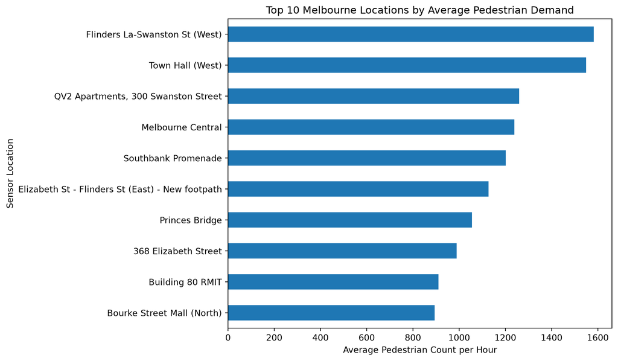

```python
# Calculate average demand by location
top_locations = (
    df.dropna(subset=["Sensor_Description"])
      .groupby("Sensor_Description")["Total_of_Directions"]
      .mean()
      .sort_values(ascending=False)
      .head(10)
      .sort_values()
)

# Plot top 10 locations
plt.figure(figsize=(10, 6))

top_locations.plot(kind="barh")

plt.title("Top 10 Melbourne Locations by Average Pedestrian Demand")
plt.xlabel("Average Pedestrian Count per Hour")
plt.ylabel("Sensor Location")
plt.tight_layout()

plt.show()
```

Pedestrian activity is highly concentrated geographically. Several central-city locations, including Flinders Lane–Swanston Street, Town Hall, Melbourne Central and Southbank Promenade, record substantially higher average hourly pedestrian volumes than other monitored locations.

## Pedestrian Demand by Day of Week

Average pedestrian demand is compared across each day of the week to identify broader weekly mobility patterns.

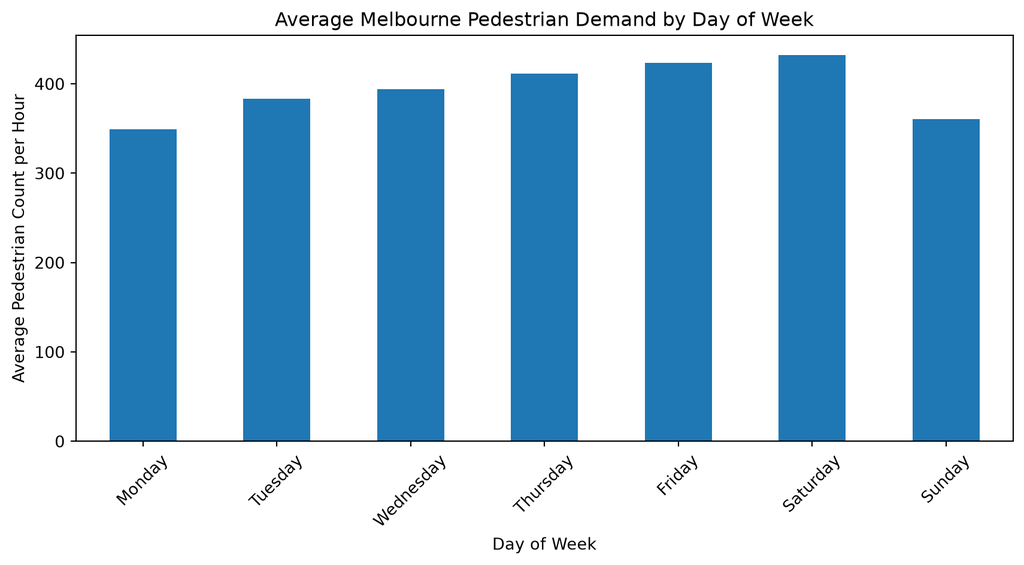

```python
# Set days in calendar order
day_order = [
    "Monday", "Tuesday", "Wednesday",
    "Thursday", "Friday", "Saturday", "Sunday"
]

# Calculate average demand by day
daily_demand = (
    df.groupby("Day_of_Week")["Total_of_Directions"]
      .mean()
      .reindex(day_order)
)

# Plot
plt.figure(figsize=(9, 5))

daily_demand.plot(kind="bar")

plt.title("Average Melbourne Pedestrian Demand by Day of Week")
plt.xlabel("Day of Week")
plt.ylabel("Average Pedestrian Count per Hour")
plt.xticks(rotation=45)
plt.tight_layout()

plt.show()
```

Average pedestrian demand varies across the week, increasing from Monday toward the end of the working week and reaching its highest level on Saturday. Sunday experiences substantially lower average demand than Saturday, indicating that individual day-of-week effects contain information beyond a simple weekday/weekend distinction.

# Statistical Analysis

## Weekday vs Weekend Demand

Exploratory analysis suggests that pedestrian demand differs between weekdays and weekends. A Mann–Whitney U test is used to assess whether the distributions of hourly pedestrian counts differ significantly between these two groups.

**Null hypothesis (H₀):** The distribution of pedestrian demand is the same for weekdays and weekends.

**Alternative hypothesis (H₁):** The distribution of pedestrian demand differs between weekdays and weekends.

```python
from scipy.stats import mannwhitneyu

# Separate pedestrian counts into weekday and weekend groups
weekday_demand = df.loc[
    df["Weekend"] == 0,
    "Total_of_Directions"
]

weekend_demand = df.loc[
    df["Weekend"] == 1,
    "Total_of_Directions"
]

# Perform Mann-Whitney U test
u_stat, p_value = mannwhitneyu(
    weekday_demand,
    weekend_demand,
    alternative="two-sided"
)

# Compare descriptive statistics
print("Weekday observations:", len(weekday_demand))
print("Weekend observations:", len(weekend_demand))

print("\nWeekday mean:", round(weekday_demand.mean(), 2))
print("Weekend mean:", round(weekend_demand.mean(), 2))

print("\nWeekday median:", round(weekday_demand.median(), 2))
print("Weekend median:", round(weekend_demand.median(), 2))

print("\nMann-Whitney U statistic:", round(u_stat, 2))
print("p-value:", p_value)
```

```
Weekday observations: 361157
Weekend observations: 144730

Weekday mean: 392.58
Weekend mean: 396.62

Weekday median: 164.0
Weekend median: 149.0

Mann-Whitney U statistic: 26280632851.0
p-value: 0.0019369064152551113
```

The distribution of pedestrian demand differs significantly between weekdays and weekends (Mann–Whitney U test, p = 0.0019). However, average demand is very similar across the two groups (392.6 vs 396.6 pedestrians per hour). This suggests that the more important distinction is not overall demand volume, but how demand is distributed throughout the day, as shown by the different hourly patterns observed in the exploratory analysis.

# Machine Learning

## Prediction Task

The modelling objective is to predict hourly pedestrian demand (`Total_of_Directions`) for individual sensor locations using temporal and location information.

To better represent a real forecasting scenario, observations are split chronologically rather than randomly. Models were trained using January–July 2026 observations and evaluated on unseen observations from 1–13 August 2026. The incomplete observations from 14 August were excluded from model evaluation.

```python
# Select features for modelling
features = [
    "Location_ID",
    "HourDay",
    "Day_Number",
    "Month",
    "Weekend"
]

target = "Total_of_Directions"

# Chronological train/test split
train = df[df["Sensing_Date"] < "2026-08-01"].copy()

test = df[
    (df["Sensing_Date"] >= "2026-08-01") &
    (df["Sensing_Date"] <= "2026-08-13")
].copy()

X_train = train[features]
y_train = train[target]

X_test = test[features]
y_test = test[target]

print("Training observations:", len(train))
print("Testing observations:", len(test))

print("\nTraining period:")
print(train["Sensing_Date"].min(), "to", train["Sensing_Date"].max())

print("\nTesting period:")
print(test["Sensing_Date"].min(), "to", test["Sensing_Date"].max())
```

```
Training observations: 476599
Testing observations: 28963

Training period:
2026-01-01 00:00:00 to 2026-07-31 00:00:00

Testing period:
2026-08-01 00:00:00 to 2026-08-13 00:00:00
```

## Baseline Model

A baseline model provides a simple benchmark against which the machine-learning models can be evaluated. The baseline predicts the mean pedestrian demand observed in the training data for every test observation.

```python
from sklearn.metrics import mean_absolute_error, mean_squared_error, r2_score
import numpy as np

# Predict the training-set mean for every test observation
baseline_prediction = np.repeat(y_train.mean(), len(y_test))

# Evaluate baseline
baseline_mae = mean_absolute_error(y_test, baseline_prediction)
baseline_rmse = np.sqrt(mean_squared_error(y_test, baseline_prediction))
baseline_r2 = r2_score(y_test, baseline_prediction)

print("Baseline prediction:", round(y_train.mean(), 2))
print("Baseline MAE:", round(baseline_mae, 2))
print("Baseline RMSE:", round(baseline_rmse, 2))
print("Baseline R²:", round(baseline_r2, 3))
```

```
Baseline prediction: 394.9
Baseline MAE: 393.16
Baseline RMSE: 569.14
Baseline R²: -0.001
```

## Linear Regression

Linear regression provides an interpretable first model for estimating pedestrian demand.

Sensor location is treated as a categorical variable rather than a numerical quantity, since `Location_ID` represents categories rather than a continuous measurement.

```python
from sklearn.compose import ColumnTransformer
from sklearn.preprocessing import OneHotEncoder
from sklearn.pipeline import Pipeline
from sklearn.linear_model import LinearRegression

# Location_ID is categorical
categorical_features = ["Location_ID"]

# Remaining features are numerical/binary
numeric_features = [
    "HourDay",
    "Day_Number",
    "Month",
    "Weekend"
]

# One-hot encode sensor locations
preprocessor = ColumnTransformer(
    transformers=[
        (
            "location",
            OneHotEncoder(
                handle_unknown="ignore",
                sparse_output=False
            ),
            categorical_features
        )
    ],
    remainder="passthrough"
)

# Build modelling pipeline
linear_model = Pipeline(
    steps=[
        ("preprocessor", preprocessor),
        ("model", LinearRegression())
    ]
)

# Train model
linear_model.fit(X_train, y_train)

# Predict August observations
linear_predictions = linear_model.predict(X_test)

# Evaluate model
linear_mae = mean_absolute_error(y_test, linear_predictions)
linear_rmse = np.sqrt(mean_squared_error(y_test, linear_predictions))
linear_r2 = r2_score(y_test, linear_predictions)

print("Linear Regression MAE:", round(linear_mae, 2))
print("Linear Regression RMSE:", round(linear_rmse, 2))
print("Linear Regression R²:", round(linear_r2, 3))
```

```
Linear Regression MAE: 288.83
Linear Regression RMSE: 438.45
Linear Regression R²: 0.406
```

## Random Forest

The Random Forest model is used to capture nonlinear relationships and interactions between temporal and location features that may not be adequately represented by linear regression.

```python
from sklearn.ensemble import RandomForestRegressor

# Build Random Forest pipeline
random_forest = Pipeline(
    steps=[
        ("preprocessor", preprocessor),
        ("model", RandomForestRegressor(
            n_estimators=100,
            max_depth=20,
            min_samples_leaf=5,
            random_state=42,
            n_jobs=-1
        ))
    ]
)

# Train model
random_forest.fit(X_train, y_train)

# Predict unseen August observations
rf_predictions = random_forest.predict(X_test)

# Evaluate model
rf_mae = mean_absolute_error(y_test, rf_predictions)
rf_rmse = np.sqrt(mean_squared_error(y_test, rf_predictions))
rf_r2 = r2_score(y_test, rf_predictions)

print("Random Forest MAE:", round(rf_mae, 2))
print("Random Forest RMSE:", round(rf_rmse, 2))
print("Random Forest R²:", round(rf_r2, 3))
```

```
Random Forest MAE: 175.07
Random Forest RMSE: 287.51
Random Forest R²: 0.745
```

Random Forest outperformed Linear Regression on the unseen August test period, reducing MAE from 288.83 to 175.07 pedestrians per sensor-hour and increasing R² from 0.406 to 0.745. This suggests that nonlinear relationships and interactions between location and temporal features are important for predicting pedestrian demand.

## Gradient Boosting

Gradient boosting is evaluated as a flexible nonlinear model capable of capturing complex interactions between location and temporal features.

```python
from sklearn.ensemble import HistGradientBoostingRegressor

gradient_boosting = Pipeline(
    steps=[
        ("preprocessor", preprocessor),
        ("model", HistGradientBoostingRegressor(
            learning_rate=0.1,
            max_iter=200,
            max_leaf_nodes=31,
            l2_regularization=1.0,
            random_state=42
        ))
    ]
)

# Train model
gradient_boosting.fit(X_train, y_train)

# Predict unseen August observations
gb_predictions = gradient_boosting.predict(X_test)

# Pedestrian counts cannot be negative
gb_predictions = np.maximum(gb_predictions, 0)

# Evaluate model
gb_mae = mean_absolute_error(y_test, gb_predictions)
gb_rmse = np.sqrt(mean_squared_error(y_test, gb_predictions))
gb_r2 = r2_score(y_test, gb_predictions)

print("Gradient Boosting MAE:", round(gb_mae, 2))
print("Gradient Boosting RMSE:", round(gb_rmse, 2))
print("Gradient Boosting R²:", round(gb_r2, 3))
```

```
Gradient Boosting MAE: 98.14
Gradient Boosting RMSE: 184.49
Gradient Boosting R²: 0.895
```

## Model Comparison

The models are compared using performance on the unseen August 2026 test period. Lower MAE and RMSE indicate smaller prediction errors, while higher R² indicates that more variation in pedestrian demand is explained by the model.

```python
# Create model comparison table
model_results = pd.DataFrame({
    "Model": [
        "Baseline",
        "Linear Regression",
        "Random Forest",
        "Gradient Boosting"
    ],
    "MAE": [
        baseline_mae,
        linear_mae,
        rf_mae,
        gb_mae
    ],
    "RMSE": [
        baseline_rmse,
        linear_rmse,
        rf_rmse,
        gb_rmse
    ],
    "R²": [
        baseline_r2,
        linear_r2,
        rf_r2,
        gb_r2
    ]
})

# Round results for presentation
model_results.round({
    "MAE": 2,
    "RMSE": 2,
    "R²": 3
})
```

|  | Model | MAE | RMSE | R² |
| --- | --- | --- | --- | --- |
| 0 | Baseline | 393.16 | 569.14 | -0.001 |
| 1 | Linear Regression | 288.83 | 438.45 | 0.406 |
| 2 | Random Forest | 175.07 | 287.51 | 0.745 |
| 3 | Gradient Boosting | 98.14 | 184.49 | 0.895 |

### Model Performance Comparison

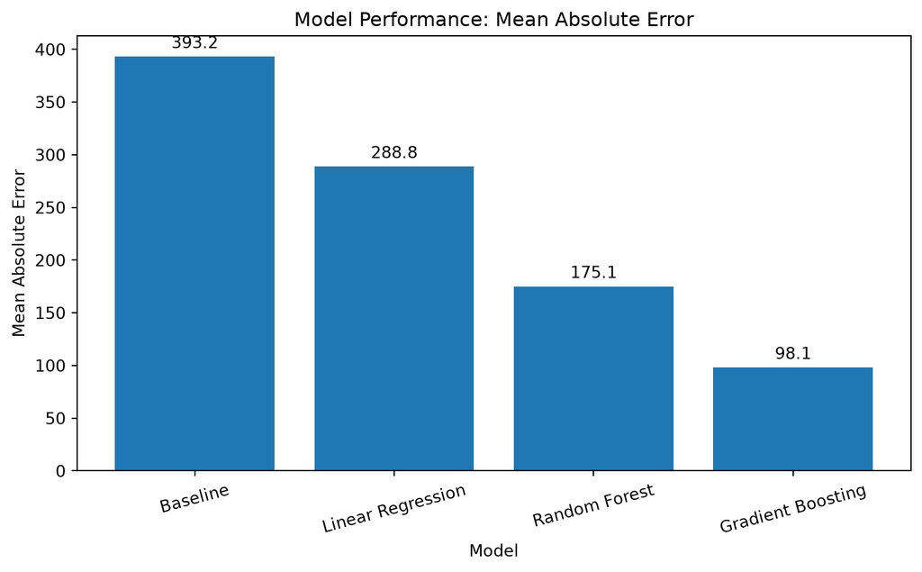

```python
model_names = [
    "Baseline",
    "Linear Regression",
    "Random Forest",
    "Gradient Boosting"
]

model_mae = [
    baseline_mae,
    linear_mae,
    rf_mae,
    gb_mae
]

plt.figure(figsize=(8, 5))

bars = plt.bar(model_names, model_mae)

plt.title("Model Performance: Mean Absolute Error")
plt.ylabel("Mean Absolute Error")
plt.xlabel("Model")

for bar, value in zip(bars, model_mae):
    plt.text(
        bar.get_x() + bar.get_width() / 2,
        bar.get_height() + 8,
        f"{value:.1f}",
        ha="center"
    )

plt.xticks(rotation=15)
plt.tight_layout()
plt.savefig("figures/model_performance.png", dpi=200, bbox_inches="tight")
plt.show()
```

Gradient boosting reduced mean absolute error from 393.16 pedestrians per sensor-hour for the baseline to 98.14, representing an approximately 75% reduction in MAE.

## Actual vs Predicted Demand

The final Gradient Boosting model is evaluated by comparing predicted pedestrian counts with the actual observations in the unseen test period.

```python
# Create prediction results
prediction_results = test[
    [
        "Sensing_Date",
        "HourDay",
        "Location_ID",
        "Sensor_Description",
        "Total_of_Directions"
    ]
].copy()

prediction_results["Predicted_Demand"] = gb_predictions

prediction_results["Absolute_Error"] = abs(
    prediction_results["Total_of_Directions"]
    - prediction_results["Predicted_Demand"]
)
```

Predictions generally track observed pedestrian demand closely, consistent with the model’s R² of 0.895. Prediction errors become more pronounced at unusually high pedestrian volumes, indicating that extreme demand spikes are more difficult to forecast from location and temporal features alone.

### Prediction Accuracy

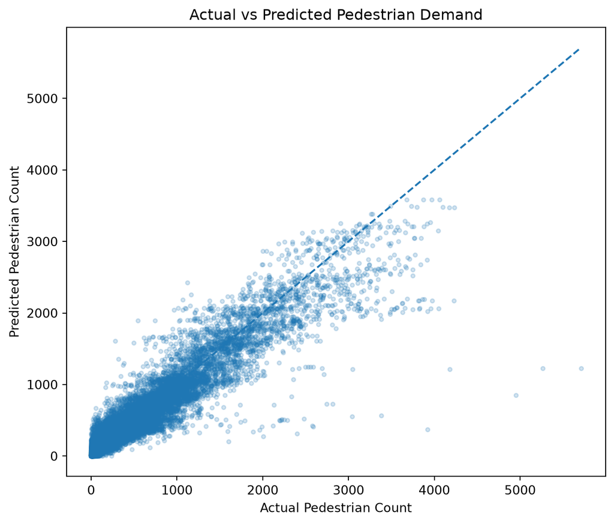

```python
plt.figure(figsize=(7, 6))

plt.scatter(
    prediction_results["Total_of_Directions"],
    prediction_results["Predicted_Demand"],
    alpha=0.2,
    s=10
)

# Perfect-prediction reference line
max_value = max(
    prediction_results["Total_of_Directions"].max(),
    prediction_results["Predicted_Demand"].max()
)

plt.plot(
    [0, max_value],
    [0, max_value],
    linestyle="--"
)

plt.title("Actual vs Predicted Pedestrian Demand")
plt.xlabel("Actual Pedestrian Count")
plt.ylabel("Predicted Pedestrian Count")
plt.tight_layout()
plt.savefig("figures/actual_vs_predicted.png", dpi=200, bbox_inches="tight")
plt.show()
```

Predicted demand generally aligns closely with observed demand, consistent with the model’s R² of 0.895. However, errors increase for some extreme high-demand observations, where the model tends to underestimate unusually large pedestrian volumes. This indicates that location and temporal patterns explain regular pedestrian activity well but do not fully capture abnormal demand spikes.

## Model Interpretation

### Permutation Feature Importance

Permutation importance is used to assess how strongly each feature contributes to predictive performance. Each feature is randomly shuffled while the remaining features are held unchanged, and the resulting deterioration in model performance is measured.

```python
from sklearn.inspection import permutation_importance

# Calculate permutation importance on the unseen test data
importance = permutation_importance(
    gradient_boosting,
    X_test,
    y_test,
    scoring="neg_mean_absolute_error",
    n_repeats=5,
    random_state=42,
    n_jobs=-1
)

feature_importance = pd.DataFrame({
    "Feature": features,
    "Importance": importance.importances_mean
}).sort_values("Importance", ascending=True)

feature_importance
```

|  | Feature | Importance |
| --- | --- | --- |
| 3 | Month | 0.000000 |
| 4 | Weekend | 0.107038 |
| 2 | Day_Number | 28.537617 |
| 1 | HourDay | 260.767353 |
| 0 | Location_ID | 289.207100 |

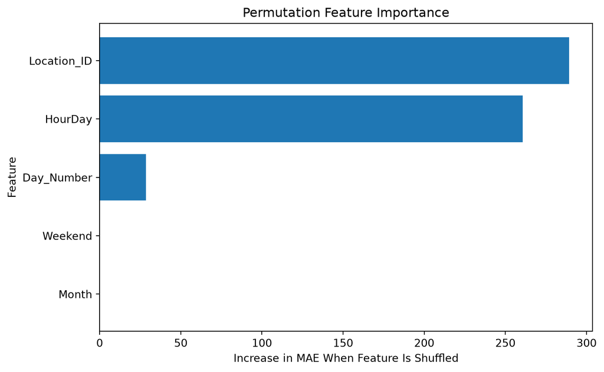

```python
# Plot feature importance
plt.figure(figsize=(8, 5))

plt.barh(
    feature_importance["Feature"],
    feature_importance["Importance"]
)

plt.title("Permutation Feature Importance")
plt.xlabel("Increase in MAE When Feature Is Shuffled")
plt.ylabel("Feature")
plt.tight_layout()

plt.show()
```

Location and hour of day are the dominant predictors of pedestrian demand, with permutation importance substantially higher than the remaining features. Day of week provides additional predictive information, while the weekend indicator contributes almost no additional information once day of week is included. Month has zero measurable permutation importance in this evaluation because the test period contains only August observations, meaning the feature has no variation within the test set.

## Error Analysis

Aggregate performance metrics can conceal important model weaknesses. Prediction errors are therefore examined across individual observations to identify conditions under which the model performs poorly.

### Largest Prediction Errors

```python
# Find the 8 largest prediction errors
largest_errors = (
    prediction_results
    .sort_values("Absolute_Error", ascending=False)
    [
        [
            "Sensing_Date",
            "HourDay",
            "Sensor_Description",
            "Total_of_Directions",
            "Predicted_Demand",
            "Absolute_Error"
        ]
    ]
    .head(8)
)

largest_errors.round(1)
```

|  | Sensing_Date | HourDay | Sensor_Description | Total_of_Directions | Predicted_Demand | Absolute_Error |
| --- | --- | --- | --- | --- | --- | --- |
| 9618 | 2026-08-09 | 12 | Building 80 RMIT | 5710 | 1224.6 | 4485.4 |
| 11192 | 2026-08-09 | 11 | Building 80 RMIT | 4954 | 853.8 | 4100.2 |
| 9849 | 2026-08-09 | 13 | Building 80 RMIT | 5265 | 1224.6 | 4040.4 |
| 13380 | 2026-08-08 | 16 | COM Pole 1120 - Towards the City, Near Federat... | 3919 | 369.6 | 3549.4 |
| 10614 | 2026-08-09 | 14 | Building 80 RMIT | 4182 | 1214.5 | 2967.5 |
| 10443 | 2026-08-09 | 10 | Building 80 RMIT | 3382 | 563.8 | 2818.2 |
| 12473 | 2026-08-08 | 16 | Birrarung Marr - COM - Pole 1109 | 3043 | 552.1 | 2490.9 |
| 24950 | 2026-08-02 | 16 | COM Pole 1120 - Towards the City, Near Federat... | 2591 | 407.9 | 2183.1 |

The largest prediction errors are concentrated around specific dates and locations rather than being evenly distributed across the test period. Several extreme underpredictions occurred around RMIT and Swanston Street on 9 August 2026, where observed pedestrian volumes were several times greater than the model’s prediction. This suggests that unusual events or other external factors can create substantial demand shocks that are not captured by the current temporal and location features.

### Prediction Error by Date

Average model error is examined across the test period to identify dates on which pedestrian behaviour deviated most strongly from historical patterns.

```python
# Calculate prediction error by date
error_by_date = (
    prediction_results
    .groupby("Sensing_Date")["Absolute_Error"]
    .mean()
    .sort_values(ascending=False)
)

error_by_date.head(10)
```

```
Sensing_Date
2026-08-09    130.097874
2026-08-01    114.628122
2026-08-10    106.635130
2026-08-08    102.956372
2026-08-05    101.875326
2026-08-02     99.616053
2026-08-04     98.604190
2026-08-13     92.132681
2026-08-06     89.515160
2026-08-11     89.223583
Name: Absolute_Error, dtype: float64
```

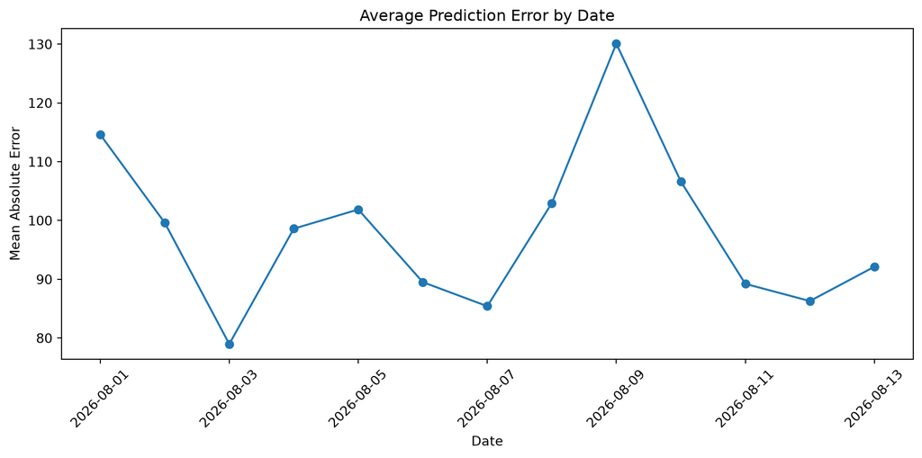

```python
# Plot average error across the test period
error_by_date_plot = error_by_date.sort_index()

plt.figure(figsize=(10, 5))

plt.plot(
    error_by_date_plot.index,
    error_by_date_plot.values,
    marker="o"
)

plt.title("Average Prediction Error by Date")
plt.xlabel("Date")
plt.ylabel("Mean Absolute Error")
plt.xticks(rotation=45)
plt.tight_layout()

plt.show()
```

Prediction error varies across the August test period, with 9 August producing the highest average error (MAE ≈ 130). Examination of the largest individual errors shows that this deterioration is concentrated around unusually high pedestrian counts at locations including RMIT and Swanston Street. This suggests that the model captures regular mobility patterns effectively but is less accurate during unusual demand spikes.

## Model Refinement

### Cyclical Time Features

Time variables have a cyclical structure that is not represented by their raw numerical values. For example, 23:00 and 00:00 are adjacent hours despite appearing numerically far apart.

Sine and cosine transformations are therefore used to represent hour of day and day of week as cyclical features.

```python
# Create cyclical time features
df["Hour_Sin"] = np.sin(2 * np.pi * df["HourDay"] / 24)
df["Hour_Cos"] = np.cos(2 * np.pi * df["HourDay"] / 24)

df["Day_Sin"] = np.sin(2 * np.pi * df["Day_Number"] / 7)
df["Day_Cos"] = np.cos(2 * np.pi * df["Day_Number"] / 7)

df[
    [
        "HourDay",
        "Hour_Sin",
        "Hour_Cos",
        "Day_Number",
        "Day_Sin",
        "Day_Cos"
    ]
].head()
```

|  | HourDay | Hour_Sin | Hour_Cos | Day_Number | Day_Sin | Day_Cos |
| --- | --- | --- | --- | --- | --- | --- |
| 0 | 0 | 0.000000 | 1.000000 | 4 | -0.433884 | -0.900969 |
| 1 | 2 | 0.500000 | 0.866025 | 4 | -0.433884 | -0.900969 |
| 2 | 3 | 0.707107 | 0.707107 | 4 | -0.433884 | -0.900969 |
| 3 | 1 | 0.258819 | 0.965926 | 4 | -0.433884 | -0.900969 |
| 4 | 0 | 0.000000 | 1.000000 | 4 | -0.433884 | -0.900969 |

### Refined Gradient Boosting Model

The refined model removes the redundant weekend indicator and replaces raw hour and day-of-week variables with cyclical representations.

```python
refined_features = [
    "Location_ID",
    "Hour_Sin",
    "Hour_Cos",
    "Day_Sin",
    "Day_Cos",
    "Month"
]

X_refined = df[refined_features]
y_refined = df["Total_of_Directions"]

# Preserve chronological train/test split
train_mask = df["Sensing_Date"] < "2026-08-01"
test_mask = (
    (df["Sensing_Date"] >= "2026-08-01") &
    (df["Sensing_Date"] <= "2026-08-13")
)

X_train_refined = X_refined[train_mask]
X_test_refined = X_refined[test_mask]

y_train_refined = y_refined[train_mask]
y_test_refined = y_refined[test_mask]

# Preprocess Location_ID as categorical
refined_preprocessor = ColumnTransformer(
    transformers=[
        (
            "location",
            OneHotEncoder(
                handle_unknown="ignore",
                sparse_output=False
            ),
            ["Location_ID"]
        )
    ],
    remainder="passthrough"
)

# Build refined model
refined_model = Pipeline(
    steps=[
        ("preprocessor", refined_preprocessor),
        (
            "model",
            HistGradientBoostingRegressor(
                max_iter=200,
                learning_rate=0.1,
                max_leaf_nodes=31,
                random_state=42
            )
        )
    ]
)

# Train
refined_model.fit(X_train_refined, y_train_refined)

# Predict
refined_predictions = refined_model.predict(X_test_refined)

# Evaluate
refined_mae = mean_absolute_error(
    y_test_refined,
    refined_predictions
)

refined_rmse = np.sqrt(
    mean_squared_error(
        y_test_refined,
        refined_predictions
    )
)

refined_r2 = r2_score(
    y_test_refined,
    refined_predictions
)

print("Original Gradient Boosting:")
print("MAE:", round(gb_mae, 2))
print("RMSE:", round(gb_rmse, 2))
print("R²:", round(gb_r2, 3))

print("\nRefined Gradient Boosting:")
print("MAE:", round(refined_mae, 2))
print("RMSE:", round(refined_rmse, 2))
print("R²:", round(refined_r2, 3))
```

```
Original Gradient Boosting:
MAE: 98.14
RMSE: 184.49
R²: 0.895

Refined Gradient Boosting:
MAE: 101.29
RMSE: 180.75
R²: 0.899
```

Cyclical encoding produced only a marginal change in predictive performance. R² increased from 0.895 to 0.899 and RMSE decreased from 184.49 to 180.75, while MAE increased slightly from 98.14 to 101.29. This suggests that the original gradient boosting model was already capable of capturing much of the nonlinear temporal structure. Given its lower MAE and simpler feature representation, the original gradient boosting model is retained as the primary model.

## Key Findings

1. **Pedestrian demand is highly location-dependent.** Central-city locations including Flinders Lane–Swanston Street, Town Hall, Melbourne Central and Southbank Promenade recorded some of the highest average pedestrian volumes.
2. **Time of day is a major driver of demand.** Activity rises sharply through the morning and remains elevated during the day, with clear differences between weekday and weekend profiles.
3. **Nonlinear machine-learning models substantially improve forecasting.** Gradient Boosting achieved an MAE of 98.14 and R² of 0.895 on unseen observations from 1–13 August, reducing MAE by approximately 75% relative to the baseline.
4. **Location and hour of day are the strongest predictive features.** Permutation importance showed substantially greater contributions from these variables than other temporal features.
5. **Extreme demand spikes remain difficult to forecast.** The largest errors were concentrated around specific locations and dates, suggesting that events, weather and transport disruptions could improve future models.

## Recommendations

The analysis suggests several practical applications for pedestrian-demand forecasting.

**Resource and staffing planning.** Predicted demand patterns could help organisations anticipate periods of high pedestrian activity and allocate staff or operational resources accordingly.

**Transport and urban planning.** Location-level demand forecasts could provide additional evidence for understanding how different parts of the city are used throughout the day and support infrastructure or accessibility planning.

**Event-aware forecasting.** The largest prediction errors indicate that unusual demand spikes require additional contextual information. Integrating event schedules, public holidays, weather and transport disruption data could improve forecasting during abnormal conditions.

**Model monitoring.** Forecast accuracy should be monitored over time as pedestrian behaviour and the sensor network evolve. Large deviations between predicted and observed demand could also be used as signals for unusual activity or changing mobility patterns.

The model should therefore be treated as a decision-support system rather than a replacement for operational judgement.

## Data Governance and Responsible Model Use

### Data Quality

No pedestrian-count observations were missing, although 1,017 records lacked descriptive sensor metadata. These observations were retained because the variables required for modelling remained available.

### Representativeness

The sensor network covers monitored locations rather than a random sample of Melbourne. Results therefore describe activity within the City of Melbourne sensor network and should not be interpreted as complete city-wide pedestrian estimates.

### Model Risk

The model performs well under recurring mobility patterns but underpredicts some extreme demand spikes. External factors such as events, weather, public holidays and transport disruptions are not currently included.

### Responsible Use

Forecasts are best used as decision-support for planning and resource allocation. Performance should be monitored over time as pedestrian behaviour and the sensor network evolve.